# slide_deck_template slides

**Obsevation**

I fond that there is 4646 bike that was used more that one time.

The data does not need much work since it's clean and not missing a lot of information. It just enhacement and some edit on the datatype.

Start_time & end_time should be converted to datatime.

Bike_id should be converted to string.

Add one colunm the day of the week

### What is the structure of your dataset?

**It is a data with 183412 rwos & 18 culonms. Moreover, the dataset was almost ready and clean it just needed a little of enhacement.**

### What is/are the main feature(s) of interest in your dataset?

**I'm most interested on what would increas the number of bike and who is more biking male or female.**

### What features in the dataset do you think will help support your investigation into your feature(s) of interest?

**days if it's week days or weekend, male or female, subscriber or customer and this is a major key to find out who is more costomer than subscriber.**

### Univariate Exploration

| bike_share_for_all_trip member_gender | No | Yes |
| --- | --- | --- |
| Female | 37244 | 3600 |
| Male | 117540 | 13111 |
| Other | 3004 | 648 |

**observation**

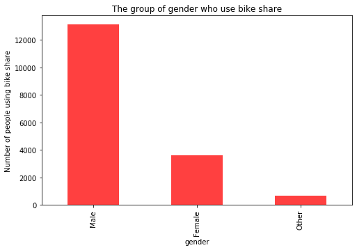

**Observation**

according to this graph, male is more interested on biking than female

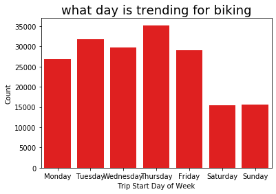

**Observation**

people are more biking on week days than weekend.

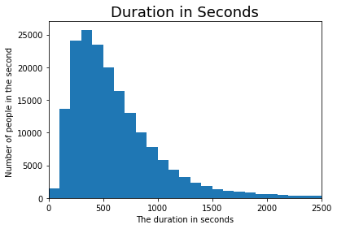

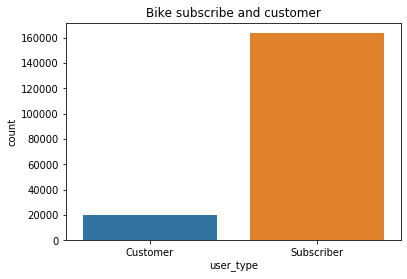

**Observation**

As it shown here, there is a huge different than the costomer & the subscriber

| user_type member_gender | Customer | Subscriber |
| --- | --- | --- |
| Female | 4647 | 36197 |
| Male | 11529 | 119122 |
| Other | 455 | 3197 |

**Observation**

There is 40,844 female and 88% of them are subscriber. On the other hand, there is 130,651 male 91% of them are subscriber.

### Discuss the distribution(s) of your variable(s) of interest. Were there any unusual points? Did you need to perform any transformations?

Acutully, I thought people would be biking in weekend more since they have more free time, but according to this data I'm assuming some or many of them are using bike to go to work.

### Of the features you investigated, were there any unusual distributions? Did you perform any operations on the data to tidy, adjust, or change the form of the data? If so, why did you do this?

Yes, I fix the start & end time and to me it's brety much clean and does not need much werk.

### Bivariate Exploration

Since I have three gender I want to comaper who bike more since they both use the bike in week days.

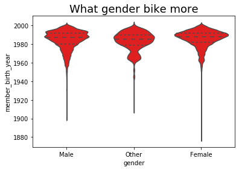

**Observation**

Now I'm interested to see who is the customers and subscribers who is older?

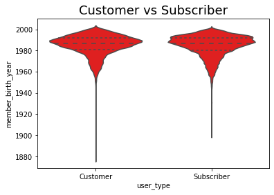

### Did you observe any interesting relationships between the other features (not the main feature(s) of interest)?

I found that (other) who did not register their gender are more male than female!

### Multivariate Exploration

Let's wrap this case study with the avgerage spend from the genders

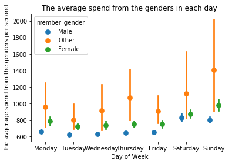

**Observation

Female are spending more than the male, however, people who did not identify their gender are spending more than the both.